# Project DADM

# 1.Introduction

# 1.1 Problem Statement

Our analysis is focussed on the problem which insurance providers are facing today to define their target market and plan their sale strategies which helps them increase their market share and thereby, maximize their profitability.

# 1.2 Model

Therefore, we have conducted our analysis using stepwise regression for ??Generalized Linear Model??(GLM) using binomial distribution and then validation the results using partial F-test and Area Under the Curve.

# 1.3 Load Libraries

```r
library(e1071) #Package for Skewness function used for data analysis
library(stats) #Package for finding cook's distance
library(ggplot2)#Package for visualisation of data
library(Amelia)#package to visually display the missing values
library(gridExtra)#Package for arranging different plots in a single grid
library(caTools)# Package for validation of models
library(pscl)# Package for Mc-Fadden R Test
library(ROCR)#Package for ROC graphs
```

# 2. Data Pre-Processing

Cross-section data originating from the Medical Expenditure Panel Survey survey conducted in 1996.

Usage data(“HealthInsurance”)

Format A data frame containing 8,802 observations on 11 variables .

Response:

limit factor. Is there any limitation?

gender factor indicating gender.

insurance factor. Does the individual have a health insurance?

married factor. Is the individual married?

selfemp factor. Is the individual self-employed?

family family size.

region factor indicating region.

ethnicity factor indicating ethnicity: African-American, Caucasian, other.

education factor indicating highest degree attained: no degree, GED (high school equivalent), high

school, bachelor, master, PhD, other.

# 2.1 Load the data

```r
library("AER")
data("HealthInsurance")
```

Initially process the data by discovering and labeling the missing data with NA; and converting categorical variable(s) to proper factors with meaningful labels.

# 2.2 FIle Structue and Content

```r
head(HealthInsurance)
```

```
##   health age limit gender insurance married selfemp family region
## 1    yes  31    no   male       yes     yes     yes      4  south
## 2    yes  31    no female       yes     yes      no      4  south
## 3    yes  54    no   male       yes     yes      no      5   west
## 4    yes  27    no   male       yes      no      no      5   west
## 5    yes  39    no   male       yes     yes      no      5   west
## 6    yes  32    no female        no      no      no      3  south
##   ethnicity  education
## 1      cauc   bachelor
## 2      cauc highschool
## 3      cauc        ged
## 4      cauc highschool
## 5      cauc       none
## 6      afam   bachelor
```

```r
str(HealthInsurance)
```

```
## 'data.frame':    8802 obs. of  11 variables:
##  $ health   : Factor w/ 2 levels "no","yes": 2 2 2 2 2 2 1 2 2 2 ...
##  $ age      : num  31 31 54 27 39 32 56 60 62 52 ...
##  $ limit    : Factor w/ 2 levels "no","yes": 1 1 1 1 1 1 2 1 1 1 ...
##  $ gender   : Factor w/ 2 levels "female","male": 2 1 2 2 2 1 1 1 2 1 ...
##  $ insurance: Factor w/ 2 levels "no","yes": 2 2 2 2 2 1 2 2 2 1 ...
##  $ married  : Factor w/ 2 levels "no","yes": 2 2 2 1 2 1 2 2 2 2 ...
##  $ selfemp  : Factor w/ 2 levels "no","yes": 2 1 1 1 1 1 1 1 1 1 ...
##  $ family   : num  4 4 5 5 5 3 2 2 2 2 ...
##  $ region   : Factor w/ 4 levels "northeast","midwest",..: 3 3 4 4 4 3 4 3 3 1 ...
##  $ ethnicity: Factor w/ 3 levels "other","afam",..: 3 3 3 3 3 2 3 3 3 2 ...
##  $ education: Factor w/ 7 levels "none","ged","highschool",..: 4 3 2 3 1 4 3 3 3 3 ...
```

# 2.3 Missing Values

```r
#To replace the possible missing values with NA
summary(HealthInsurance)
```

```
##  health          age        limit         gender     insurance  married
##  no : 629   Min.   :18.00   no :7571   female:4169   no :1750   no :3369
##  yes:8173   1st Qu.:30.00   yes:1231   male  :4633   yes:7052   yes:5433
##             Median :39.00
##             Mean   :38.94
##             3rd Qu.:48.00
##             Max.   :62.00
##
##  selfemp        family             region     ethnicity
##  no :7731   Min.   : 1.000   northeast:1682   other: 365
##  yes:1071   1st Qu.: 2.000   midwest  :2023   afam :1083
##             Median : 3.000   south    :3075   cauc :7354
##             Mean   : 3.094   west     :2022
##             3rd Qu.: 4.000
##             Max.   :14.000
##
##       education
##  none      :1119
##  ged       : 374
##  highschool:4434
##  bachelor  :1549
##  master    : 524
##  phd       : 135
##  other     : 667
```

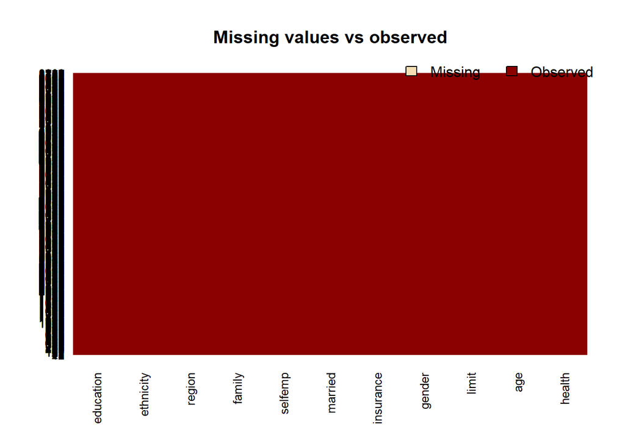

```r
HealthInsurance$age[HealthInsurance$age==0]<- NA
HealthInsurance$family[HealthInsurance$family==0]<- NA

#To Verify that the data is complete
#install.packages("Amelia")

missmap(HealthInsurance, main = "Missing values vs observed")
```

# 2.4 Validating Total factor variable in dataset.

```r
is.factor(HealthInsurance$ethnicity)
```

```
## [1] TRUE
```

```r
is.factor(HealthInsurance$health)
```

```
## [1] TRUE
```

```r
is.factor(HealthInsurance$limit)
```

```
## [1] TRUE
```

```r
is.factor(HealthInsurance$gender)
```

```
## [1] TRUE
```

```r
is.factor(HealthInsurance$age)
```

```
## [1] FALSE
```

```r
is.factor(HealthInsurance$insurance)
```

```
## [1] TRUE
```

```r
is.factor(HealthInsurance$selfemp)
```

```
## [1] TRUE
```

```r
is.factor(HealthInsurance$family)
```

```
## [1] FALSE
```

```r
is.factor(HealthInsurance$region)
```

```
## [1] TRUE
```

```r
is.factor(HealthInsurance$married)
```

```
## [1] TRUE
```

```r
is.factor(HealthInsurance$education)
```

```
## [1] TRUE
```

```r
#We can see that all the variables are factor except age and family variables.
```

For Better understanding, of how R is going to deal with the categorical variables, we can use the contrasts() function for the factors.

```r
contrasts(HealthInsurance$health)
```

```
##     yes
## no    0
## yes   1
```

```r
contrasts(HealthInsurance$limit)
```

```
##     yes
## no    0
## yes   1
```

```r
contrasts(HealthInsurance$gender)
```

```
##        male
## female    0
## male      1
```

```r
contrasts(HealthInsurance$insurance)
```

```
##     yes
## no    0
## yes   1
```

```r
contrasts(HealthInsurance$married)
```

```
##     yes
## no    0
## yes   1
```

```r
contrasts(HealthInsurance$selfemp)
```

```
##     yes
## no    0
## yes   1
```

```r
contrasts(HealthInsurance$region)
```

```
##           midwest south west
## northeast       0     0    0
## midwest         1     0    0
## south           0     1    0
## west            0     0    1
```

```r
contrasts(HealthInsurance$ethnicity)
```

```
##       afam cauc
## other    0    0
## afam     1    0
## cauc     0    1
```

```r
contrasts(HealthInsurance$education)
```

```
##            ged highschool bachelor master phd other
## none         0          0        0      0   0     0
## ged          1          0        0      0   0     0
## highschool   0          1        0      0   0     0
## bachelor     0          0        1      0   0     0
## master       0          0        0      1   0     0
## phd          0          0        0      0   1     0
## other        0          0        0      0   0     1
```

It can be said that the raw data taken is a processed data and does not need any cleaning or formatting.

# 3 Exploratory Data Visualisation :

# 3.1 Scatter plots for Continous Variable

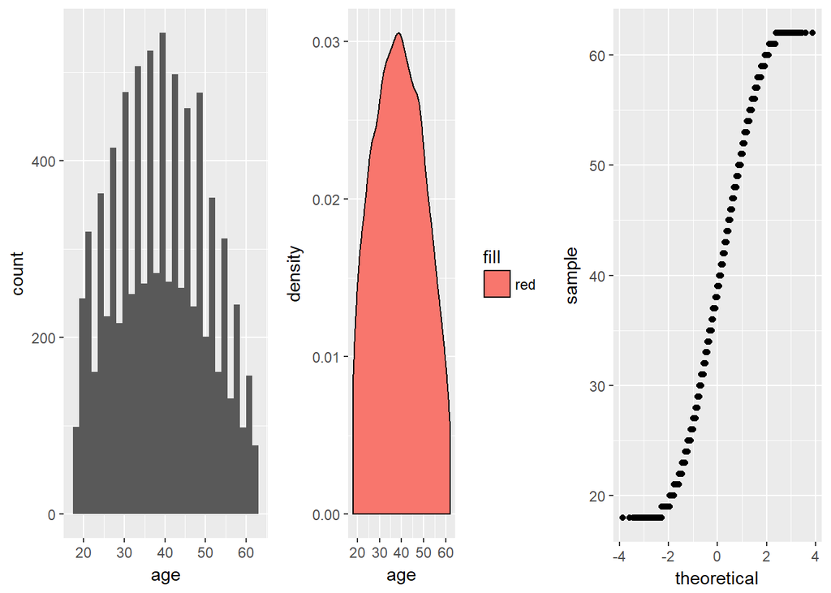

```r
#pairs(~health,age,limit,gender,insurance,married,selfemp,family,region,tehnicity,education , data=HealthInsurance)
#Unlike pairs(), ggpairs() works with non-numeric
#predictors in addition to numeric ones.
# Hence we use simple plot for the output.

plot1 = qplot(age, data = HealthInsurance, xlab = "age")
plot2 = qplot(age, data = HealthInsurance, geom = "density", fill = "red")
plot3 = qplot(sample = age, data = HealthInsurance)
grid.arrange(plot1, plot2, plot3, ncol = 3)
```

```r
#plot4 = qplot(family, data = HealthInsurance, xlab = "Evaluation")
#plot5 = qplot(family, data = HealthInsurance, geom = "density", fill = "red")
#plot6 = qplot(sample = family, data = HealthInsurance)
#grid.arrange(plot4, plot5, plot6, ncol = 3)
```

Inference: On observing the density plot graph , we can conclude that variable age is normally distributed and not skewed as the normal distribution graph is neither left nor right skewed. Since the variable is not skewed so we need not use any tranformations like log or sqrt to make age variable normally distributed.

We can observe that the age is uniformly clustered around qauantile[-4:4]

# 3.2 Skewness

We can also check the skewness using skewness() function:

```r
skewness(HealthInsurance$age)
```

```
## [1] 0.07341805
```

```r
skewness(HealthInsurance$family)
```

```
## [1] 0.9832373
```

It can be seen that skewness factor is close to zero for age so we can say that age is not skewed. However, family variable exhibit right skewness as the values is positive hence we can use log or sqrt tranformation for the same.

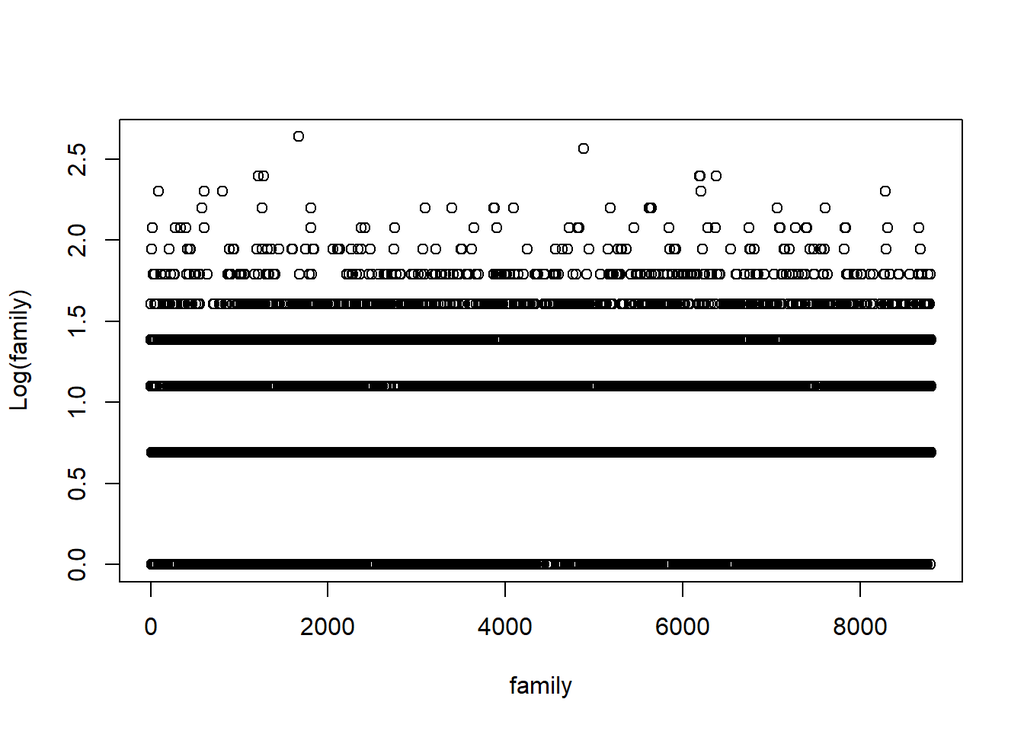

```r
log.y<-log(HealthInsurance$family)
plot(log.y,xlab="family",ylab="Log(family)")
```

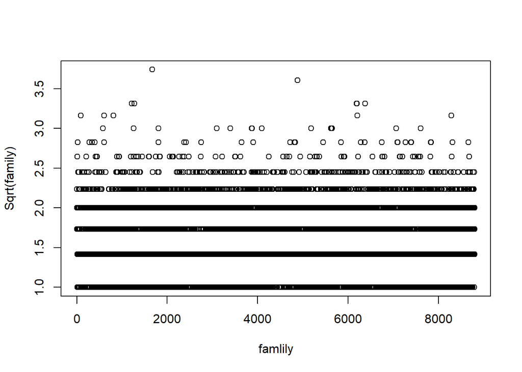

```r
sqrt.y<-sqrt(HealthInsurance$family)
plot(sqrt.y,xlab="famlily",ylab="Sqrt(family)")
```

# 3.3 BoxPlots and Stripcharts

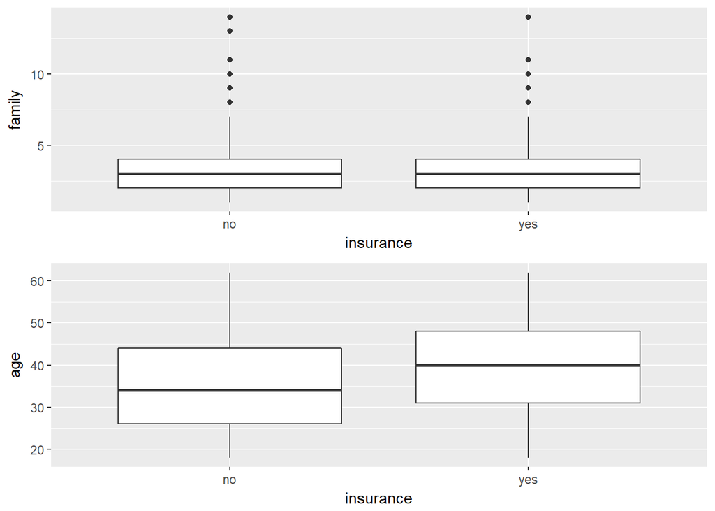

```r
plot4<- qplot(insurance,family, data=HealthInsurance, geom=c("boxplot"))
plot5<- qplot(insurance,age, data=HealthInsurance, geom=c("boxplot"))

grid.arrange(plot4, plot5)
```

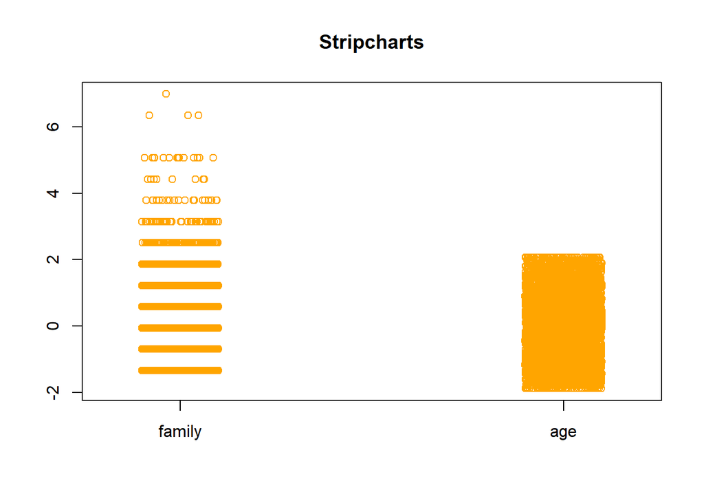

```r
numeric_data <- HealthInsurance[,c("family","age")]
numeric_data <- data.frame(scale(numeric_data ))
stripchart(numeric_data,
           vertical = TRUE,
           method = "jitter",
           col = "orange",
           pch=1,
           main="Stripcharts")
```

Visual Inspection between the 2 continous variables: Family vs insurance box plot tells us that there is considerable amount of potential outliers for family variable

# 3.4 Z-Scores Scaling

```r
healthinsurance_r = data.frame(scale(numeric_data))
summary(numeric_data)
```

```
##      family              age
##  Min.   :-1.34230   Min.   :-1.884364
##  1st Qu.:-0.70113   1st Qu.:-0.804336
##  Median :-0.05995   Median : 0.005685
##  Mean   : 0.00000   Mean   : 0.000000
##  3rd Qu.: 0.58122   3rd Qu.: 0.815706
##  Max.   : 6.99299   Max.   : 2.075739
```

The mean after rescaling the variables is 0 for both the variables. Checking the 1st and 3rd quantiles for both the variables we can infer that they lie between -2 and +2 with few exceptions.

We will now plot boxplot and strip charts on the basis of z-score

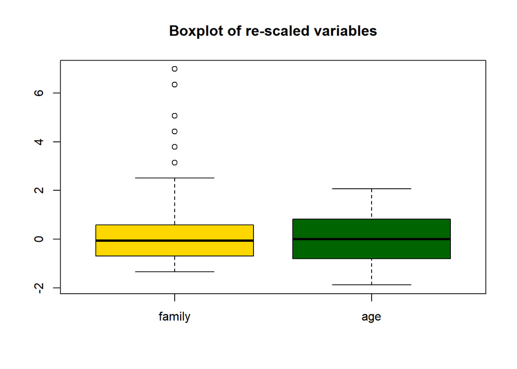

```r
boxplot(numeric_data, main = "Boxplot of re-scaled variables",col = (c("gold","darkgreen")))
```

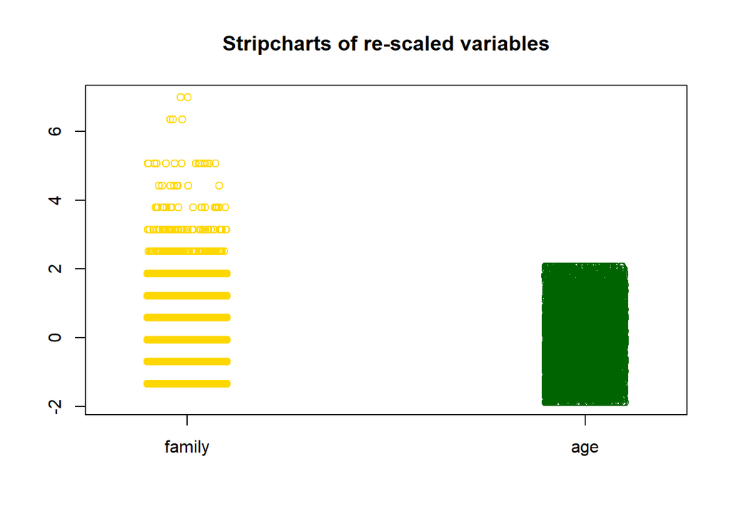

```r
stripchart(numeric_data, vertical = TRUE, method = "jitter", col = (c("gold","darkgreen")), pch = 1, main = "Stripcharts of re-scaled variables")
```

It provides confirmation of the variable transformations as all the variables now have mean 0. Also , the number of potential outliers are distinctly visible for family after z-score tranformations.

# 3.5 Correlation Matrix

```r
cor(numeric_data)
```

```
##            family        age
## family  1.0000000 -0.1314596
## age    -0.1314596  1.0000000
```

Family and age have inverse relation which should not be the case as family is directly related with age of the person.

# 3.6 CHI Square Test of Independence

The Chi Square test of independence is used to determine if there is a significant relationship between two categorical variables.

```r
a.data <- data.frame(HealthInsurance$insurance, HealthInsurance$health)
a.data = table(HealthInsurance$insurance, HealthInsurance$health)
print(a.data)
```

```
##
##         no  yes
##   no   171 1579
##   yes  458 6594
```

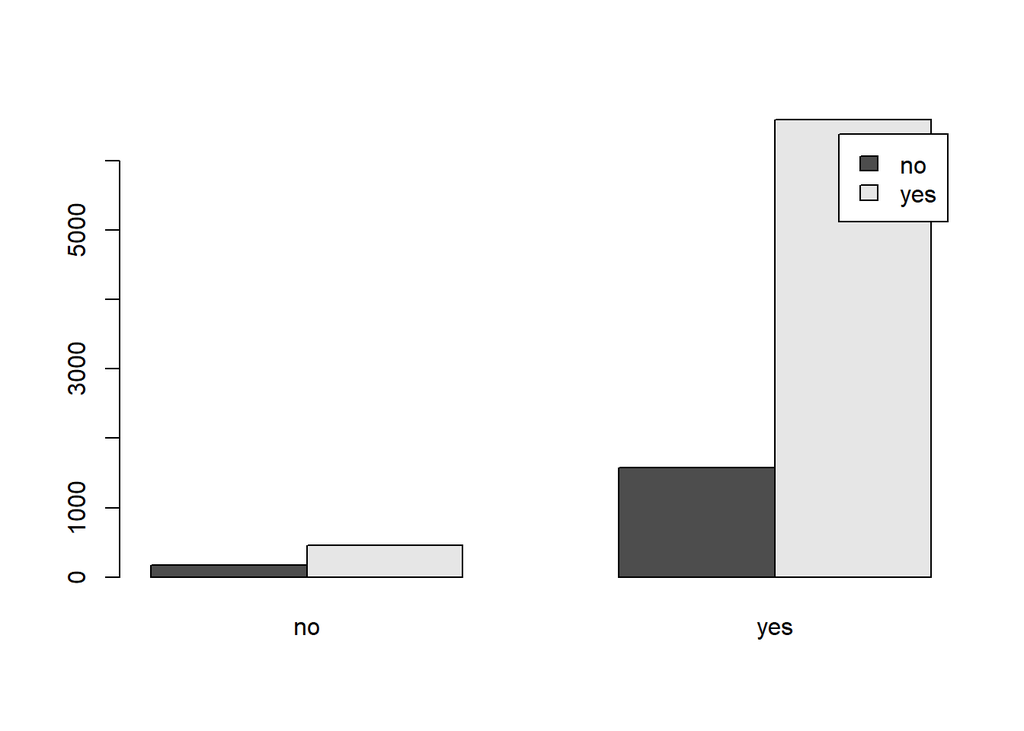

```r
barplot(a.data, beside = TRUE, legend = levels(unique(HealthInsurance$health)))
```

```r
print(chisq.test(a.data))
```

```
##
##  Pearson's Chi-squared test with Yates' continuity correction
##
## data:  a.data
## X-squared = 22.197, df = 1, p-value = 2.46e-06
```

```r
a.data <- data.frame(HealthInsurance$insurance, HealthInsurance$limit)
a.data = table(HealthInsurance$insurance, HealthInsurance$limit)
print(a.data)
```

```
##
##         no  yes
##   no  1519  231
##   yes 6052 1000
```

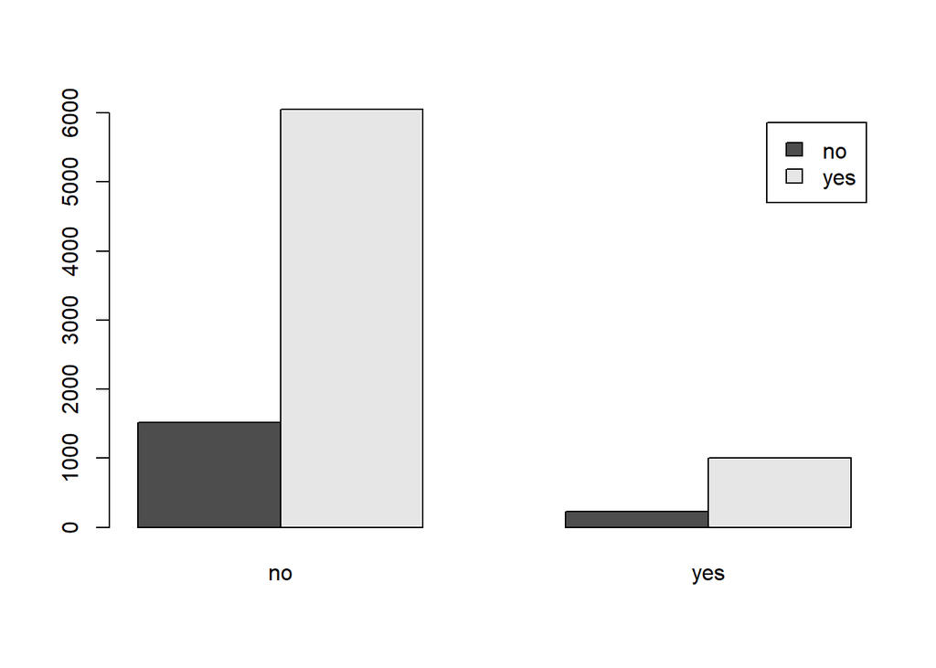

```r
barplot(a.data, beside = TRUE, legend = levels(unique(HealthInsurance$limit)))
```

```r
print(chisq.test(a.data))
```

```
##
##  Pearson's Chi-squared test with Yates' continuity correction
##
## data:  a.data
## X-squared = 1.0402, df = 1, p-value = 0.3078
```

```r
a.data <- data.frame(HealthInsurance$insurance, HealthInsurance$gender)
a.data = table(HealthInsurance$insurance, HealthInsurance$gender)
print(a.data)
```

```
##
##       female male
##   no     715 1035
##   yes   3454 3598
```

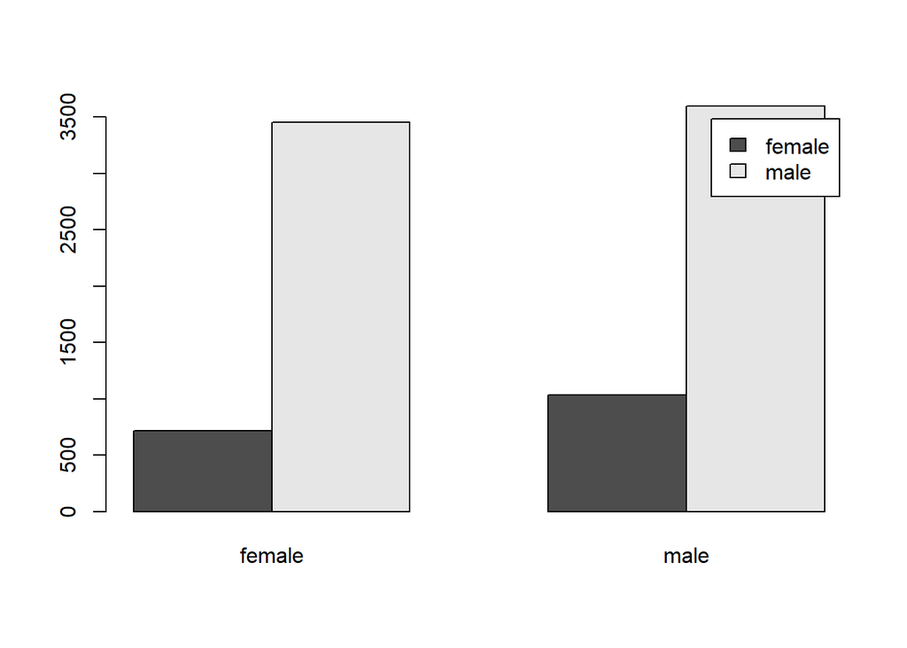

```r
barplot(a.data, beside = TRUE, legend = levels(unique(HealthInsurance$gender)))
```

```r
print(chisq.test(a.data))
```

```
##
##  Pearson's Chi-squared test with Yates' continuity correction
##
## data:  a.data
## X-squared = 36.773, df = 1, p-value = 1.327e-09
```

```r
a.data <- data.frame(HealthInsurance$insurance, HealthInsurance$married)
a.data = table(HealthInsurance$insurance, HealthInsurance$married)
print(a.data)
```

```
##
##         no  yes
##   no   976  774
##   yes 2393 4659
```

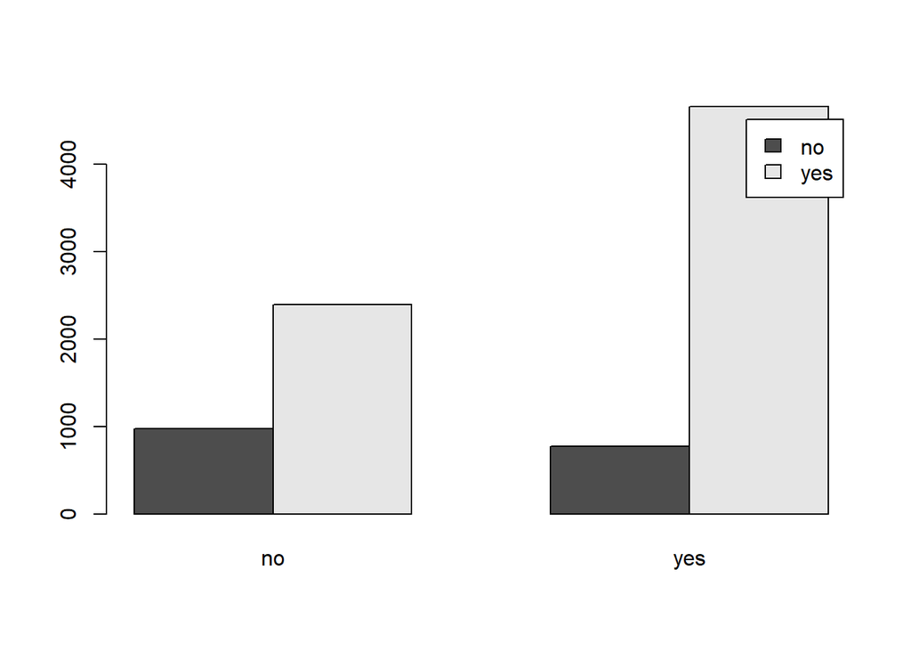

```r
barplot(a.data, beside = TRUE, legend = levels(unique(HealthInsurance$married)))
```

```r
print(chisq.test(a.data))
```

```
##
##  Pearson's Chi-squared test with Yates' continuity correction
##
## data:  a.data
## X-squared = 282.09, df = 1, p-value < 2.2e-16
```

```r
a.data <- data.frame(HealthInsurance$insurance, HealthInsurance$selfemp)
a.data = table(HealthInsurance$insurance, HealthInsurance$selfemp)
print(a.data)
```

```
##
##         no  yes
##   no  1417  333
##   yes 6314  738
```

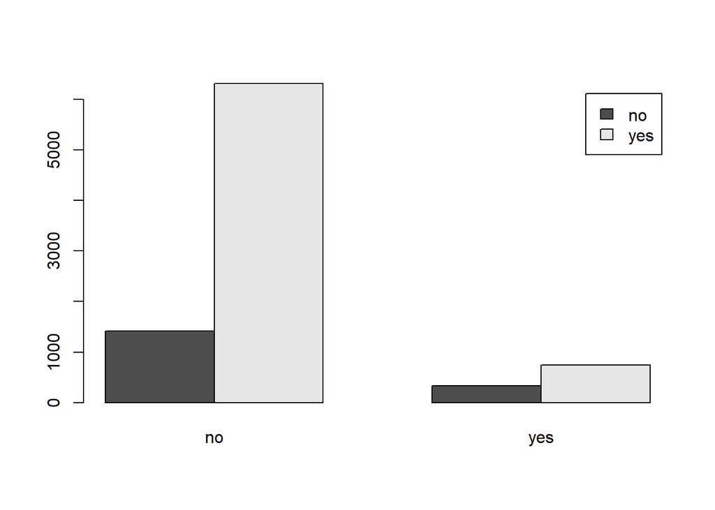

```r
barplot(a.data, beside = TRUE, legend = levels(unique(HealthInsurance$selfemp)))
```

```r
print(chisq.test(a.data))
```

```
##
##  Pearson's Chi-squared test with Yates' continuity correction
##
## data:  a.data
## X-squared = 95.407, df = 1, p-value < 2.2e-16
```

```r
a.data <- data.frame(HealthInsurance$insurance, HealthInsurance$region)
a.data = table(HealthInsurance$insurance, HealthInsurance$region)
print(a.data)
```

```
##
##       northeast midwest south west
##   no        283     296   673  498
##   yes      1399    1727  2402 1524
```

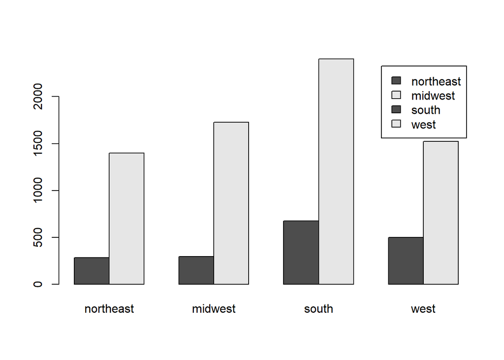

```r
barplot(a.data, beside = TRUE, legend = levels(unique(HealthInsurance$region)))
```

```r
print(chisq.test(a.data))
```

```
##
##  Pearson's Chi-squared test
##
## data:  a.data
## X-squared = 81.234, df = 3, p-value < 2.2e-16
```

```r
a.data <- data.frame(HealthInsurance$insurance, HealthInsurance$ethnicity)
a.data = table(HealthInsurance$insurance, HealthInsurance$ethnicity)
print(a.data)
```

```
##
##       other afam cauc
##   no     90  259 1401
##   yes   275  824 5953
```

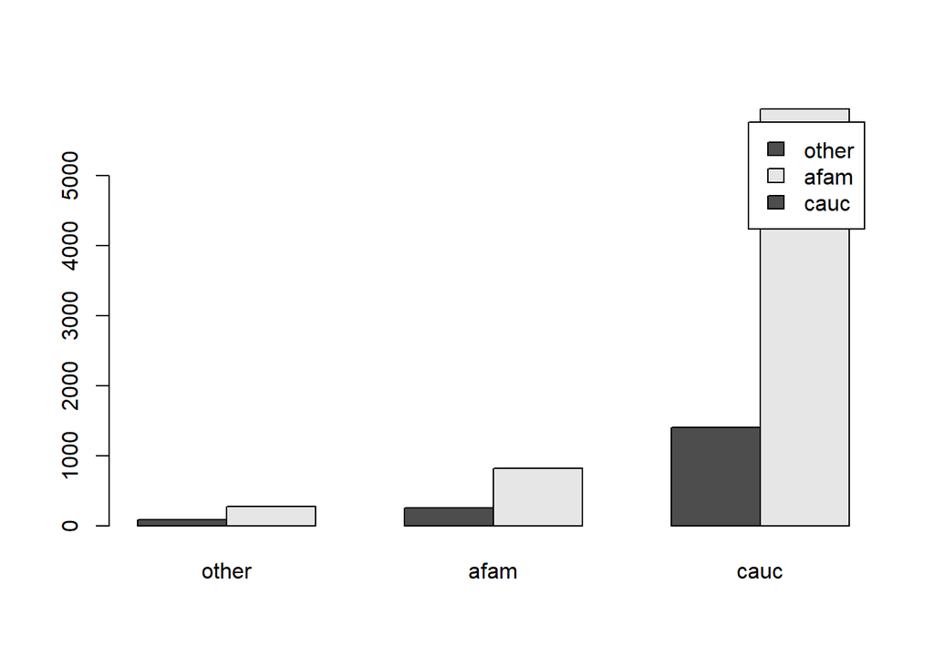

```r
barplot(a.data, beside = TRUE, legend = levels(unique(HealthInsurance$ethnicity)))
```

```r
print(chisq.test(a.data))
```

```
##
##  Pearson's Chi-squared test
##
## data:  a.data
## X-squared = 19.474, df = 2, p-value = 5.906e-05
```

```r
a.data <- data.frame(HealthInsurance$insurance, HealthInsurance$education)
a.data = table(HealthInsurance$insurance, HealthInsurance$education)
print(a.data)
```

```
##
##       none  ged highschool bachelor master  phd other
##   no   518  109        828      167     33    8    87
##   yes  601  265       3606     1382    491  127   580
```

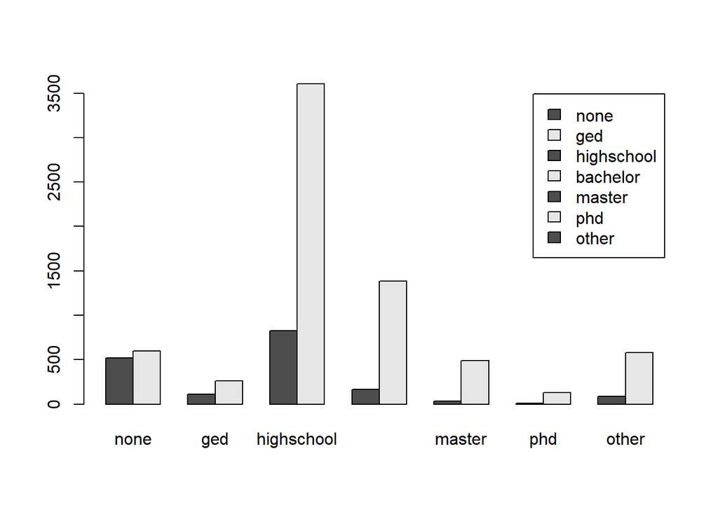

```r
barplot(a.data, beside = TRUE, legend = levels(unique(HealthInsurance$education)))
```

```r
print(chisq.test(a.data))
```

```
##
##  Pearson's Chi-squared test
##
## data:  a.data
## X-squared = 691.5, df = 6, p-value < 2.2e-16
```

We can infer by Chi Square test that the variable limit is relatively insignificant as compared to other variables.